# ISYE 6740 - Homework 1

## Question 1: Image compression using clustering

#### Note: The individual steps of the k-means algorithm are displayed below before putting them all together in the "Full Process - Question 1.1" section

Importing libraries and football.bmp image

```python
import numpy as np
from PIL import Image
import numpy as np
import time
import matplotlib.pyplot as plt
from scipy.sparse import csc_matrix, find
from itertools import combinations
import copy
from skimage import io

# import .bmp image as a numpy array
#img = np.array(Image.open('data/football.bmp'))
img = np.array(Image.open('data/GeorgiaTech.bmp'))
```

Referenced: https://stackoverflow.com/questions/10439104/reading-bmp-files-in-python

```python
# image shape is (412, 620, 3)
print(img.shape)

# reshape to 1 row/pixel
pixels = img.reshape(img.shape[0]*img.shape[1], 3)

# data shape is now (255440, 3)
print(pixels.shape)
```

```
(400, 400, 3)
(160000, 3)
```

### Randomly initialize cluster centers

```python
n = pixels.shape[1]

k = 2

c = np.zeros((k, n))

for i in range(k):

    c[i, 0] = np.clip(pixels[random.randint(0,pixels.shape[0]), 0],0,245)
    c[i, 1] = np.clip(pixels[random.randint(0,pixels.shape[0]), 1],0,245)
    c[i, 2] = np.clip(pixels[random.randint(0,pixels.shape[0]), 2],0,245)

c
```

```
array([[ 64.,  43.,  93.],
       [ 70., 153.,  92.]])
```

### REPEAT: a) Assign pixels to nearest cluster and b) adjust cluster centers

```python
c_updated = copy.deepcopy(c) + 10
labels = np.zeros(pixels.shape[0])

start_time = time.time()

while np.linalg.norm(c - c_updated, ord='fro') > 10:

    c = c_updated.copy()

    # updating label assignments
    for i in range(pixels.shape[0]):

        dist = np.zeros(c.shape[0])

        for j in range(c.shape[0]):
            dist[j] = np.linalg.norm(pixels[i] - c[j])

        labels[i] = np.argmin(dist)


    # adjust cluster centers
    for i in range(c.shape[0]):
        subset = pixels[np.where(labels == i)]
        c_updated[i] = np.nan_to_num(c_updated[i])
        c_updated[i] = (int(pixels[np.where(labels == i)][:,0].mean()),int(pixels[np.where(labels == i)][:,1].mean()),int(pixels[np.where(labels == i)][:,2].mean()))

    #print(c[0])
    print(c_updated[0])


print("--- %s seconds ---" % (time.time() - start_time))

#print(c)
#print(labels[50:100])
#print(pixels[np.where(labels == 0)])
```

```
[77. 60. 41.]
[62. 56. 44.]
[60. 56. 45.]
--- 9.789340734481812 seconds ---
```

### Display compressed image

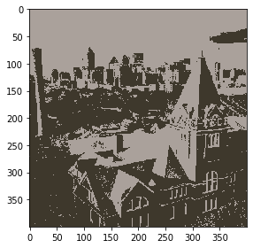

```python
h, w = img.shape[0], img.shape[1]
labels = np.reshape(labels, (h, w))

output = np.ones((h, w, 3), dtype = np.uint8)

output[:,:,:] = c[labels.astype(int),:]

io.imshow(output)
```

### Full Process - Question 1.1

The k_means_compress function below takes 2 inputs (image pixel values and k, the number of desired clusters) and returns 2 outputs (each pixel's assigned cluster label and the values of the clustering centroids).

The k_means_compress function has 3 main steps:

```
1) Randomly initialize cluster centers
2) Repeatedly 1) assign pixels to their nearest cluster and 2) adjust cluster centers to the average pixel value of those assigned to it until the centroid locations stop changing significantly
3) Display compressed image using a number of pixel values equal to the number of set cluster centers
```

**Note:** I used the image files as my input, rather than the pixels array, in order to retain the dimensions of the original image for eventually outputting a compressed image. This can be easily switched back to inputs=(pixels, k) by performing the pixels calculation outside of the 'k_means_compress' function but I thought it was helpful to display the compressed image.

```python
def k_means_compress(image, k):

    pixels = image.reshape(image.shape[0]*image.shape[1], 3)

    n = pixels.shape[1]

    c = np.zeros((k, n))

    for i in range(k):

        c[i, 0] = np.clip(pixels[random.randint(0,pixels.shape[0]), 0],0,245)
        c[i, 1] = np.clip(pixels[random.randint(0,pixels.shape[0]), 1],0,245)
        c[i, 2] = np.clip(pixels[random.randint(0,pixels.shape[0]), 2],0,245)

    c_updated = copy.deepcopy(c) + 10
    labels = np.zeros(pixels.shape[0])

    start_time = time.time()

    iterations = 0

    # from kmeans demo code
    while np.linalg.norm(c - c_updated, ord='fro') > 10:

        c = c_updated.copy()

        # updating label assignments
        for i in range(pixels.shape[0]):

            dist = np.zeros(c.shape[0])

            for j in range(c.shape[0]):
                dist[j] = np.linalg.norm(pixels[i] - c[j])

            labels[i] = np.argmin(dist)

        # adjust cluster centers
        for i in range(c.shape[0]):
            subset = pixels[np.where(labels == i)]
            c_updated[i] = (int(np.nan_to_num(pixels[np.where(labels == i)][:,0].mean()))
                            ,int(np.nan_to_num(pixels[np.where(labels == i)][:,1].mean()))
                            ,int(np.nan_to_num(pixels[np.where(labels == i)][:,2].mean())))

        iterations+=1

    print("--- %s seconds ---" % (time.time() - start_time))
    print("--- %s iterations ---" % (iterations))

    h, w = image.shape[0], image.shape[1]

    cluster_assignment = labels.copy()
    labels = np.reshape(labels, (h, w))

    output = np.ones((h, w, 3), dtype = np.uint8)

    output[:,:,:] = c[labels.astype(int),:]

    io.imshow(output)

    return cluster_assignment, c_updated
```

#### football.bmp

Below are the runtimes and iterations for k-means clustering convergence for the football.bmp image compression:

Compressed images are displayed in order below, along with 1) each pixel's class and 2) centroid locations.

```python
# import .bmp image as a numpy array
img_football = np.array(Image.open('data/football.bmp'))
```

```
--- 9.3910231590271 seconds ---
--- 2 iterations ---
```

```
(array([1., 1., 1., ..., 1., 1., 1.]), array([[192., 185., 175.],
        [ 77.,  78.,  68.]]))
```

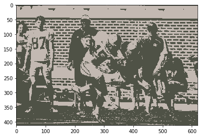

```python
k_means_compress(img_football, 2)
```

```
--- 132.76101970672607 seconds ---
--- 10 iterations ---
```

```
(array([1., 1., 2., ..., 1., 1., 1.]), array([[211., 214., 215.],
        [121., 115.,  91.],
        [ 36.,  42.,  46.],
        [177., 162., 144.]]))
```

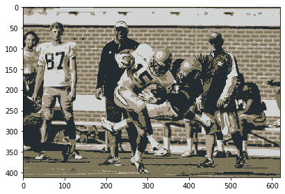

```python
k_means_compress(img_football, 4)
```

```
--- 138.3072111606598 seconds ---
--- 9 iterations ---
```

```
(array([5., 5., 5., ..., 7., 7., 7.]), array([[214., 219., 223.],
        [110.,  23.,  20.],
        [186., 174., 157.],
        [165., 119.,  94.],
        [ 27.,  28.,  25.],
        [ 82.,  80.,  61.],
        [ 24.,  63., 116.],
        [115., 132., 105.]]))
```

[figure not shown]

```python
k_means_compress(img_football, 8)
```

```
--- 343.7740070819855 seconds ---
--- 11 iterations ---
```

```
(array([0., 0., 0., ..., 3., 3., 3.]), array([[ 85.,  87.,  68.],
        [ 92., 106., 121.],
        [191., 188., 181.],
        [117., 139.,  87.],
        [165., 108.,  84.],
        [ 15.,  36.,  67.],
        [130., 143., 155.],
        [ 42.,  38.,  24.],
        [217., 223., 226.],
        [131.,  97.,  77.],
        [ 64.,  62.,  45.],
        [ 14.,  14.,  15.],
        [ 22.,  66., 123.],
        [170., 142., 114.],
        [139.,  18.,  23.],
        [191., 168., 141.]]))
```

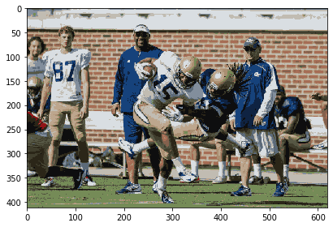

```python
k_means_compress(img_football, 16)
```

#### GeorgiaTech.bmp

Below are the runtimes and iterations for k-means clustering convergence for the GeorgiaTech.bmp image compression:

- k=2: 12 second runtime, 4 iterations
- k=4: 21 second runtime, 4 iterations
- k=8: 65 second runtime, 7 iterations
- k=16: 155 second runtime, 9 iterations

Compressed images are displayed in order below, along with 1) each pixel's class and 2) centroid locations.

```python
# import .bmp image as a numpy array
img_gatech = np.array(Image.open('data/GeorgiaTech.bmp'))
```

```
--- 11.551669120788574 seconds ---
--- 4 iterations ---
```

```
(array([1., 1., 1., ..., 0., 0., 0.]), array([[ 60.,  56.,  46.],
        [172., 161., 153.]]))
```

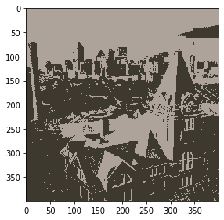

```python
k_means_compress(img_gatech, 2)
```

```
--- 20.681691884994507 seconds ---
--- 4 iterations ---
```

```
(array([1., 1., 1., ..., 2., 2., 2.]), array([[ 99.,  97.,  84.],
        [166., 175., 184.],
        [ 42.,  40.,  34.],
        [207., 144.,  92.]]))
```

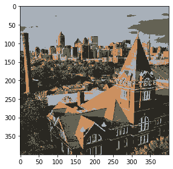

```python
k_means_compress(img_gatech, 4)
```

```
--- 64.97340726852417 seconds ---
--- 7 iterations ---
```

```
(array([0., 0., 0., ..., 3., 3., 3.]), array([[231., 211., 197.],
        [100.,  92.,  89.],
        [ 46.,  60.,  66.],
        [ 39.,  32.,  24.],
        [143., 160., 177.],
        [209., 145.,  94.],
        [ 83., 128., 155.],
        [119.,  92.,  36.]]))
```

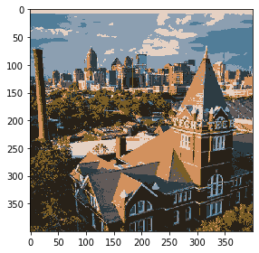

```python
k_means_compress(img_gatech, 8)
```

```
--- 154.70340085029602 seconds ---
--- 9 iterations ---
```

```
(array([11., 11., 11., ...,  7.,  7.,  7.]), array([[ 33.,  29.,  26.],
        [208., 156., 109.],
        [ 22.,  20.,  17.],
        [140., 160., 179.],
        [144., 118., 100.],
        [ 12.,  10.,  10.],
        [140., 106.,  41.],
        [ 56.,  43.,  29.],
        [209., 184., 170.],
        [ 88.,  87.,  88.],
        [ 91.,  75.,  31.],
        [251., 244., 236.],
        [ 39.,  60.,  72.],
        [  4.,   2.,   3.],
        [235., 118.,  44.],
        [ 86., 132., 160.]]))
```

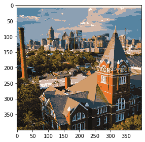

```python
k_means_compress(img_gatech, 16)
```

#### XING_B24.bmp (my sample image)

Below are the runtimes and iterations for k-means clustering convergence for the XING_B24.bmp image compression:

Compressed images are displayed in order below, along with 1) each pixel's class and 2) centroid locations.

```python
# import .bmp image as a numpy array
img_flower = np.array(Image.open('data/XING_B24.bmp'))
#img_flower = img_flower.reshape(img_flower.shape[0]*img_flower.shape[1], 3)
```

```
--- 2.8300390243530273 seconds ---
--- 4 iterations ---
```

```
(array([0., 0., 0., ..., 0., 0., 0.]), array([[124.,  75.,  74.],
        [200., 183., 171.]]))
```

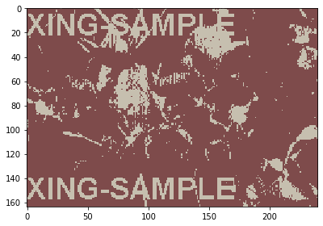

```python
k_means_compress(img_flower, 2)
```

```
--- 9.271649837493896 seconds ---
--- 7 iterations ---
```

```
(array([2., 2., 2., ..., 2., 2., 2.]), array([[230.,  52.,  99.],
        [226., 210., 167.],
        [ 73.,  88.,  63.],
        [121., 191., 190.]]))
```

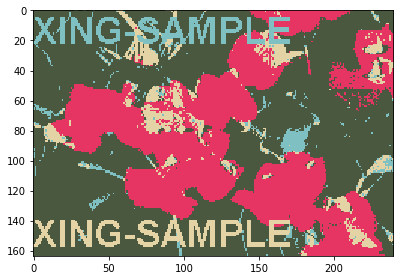

```python
k_means_compress(img_flower, 4)
```

```
--- 14.494359493255615 seconds ---
--- 6 iterations ---
```

```
(array([7., 7., 7., ..., 2., 2., 2.]), array([[237.,  38.,  93.],
        [112., 136.,  98.],
        [ 45.,  53.,  40.],
        [153.,  50.,  67.],
        [222., 216., 170.],
        [102., 215., 243.],
        [245.,  86., 126.],
        [ 69.,  99.,  65.]]))
```

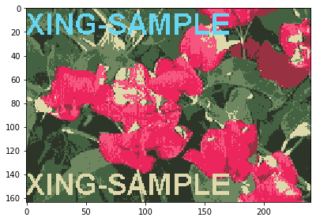

```python
k_means_compress(img_flower, 8)
```

```
--- 28.054656505584717 seconds ---
--- 6 iterations ---
```

```
(array([15., 15.,  9., ...,  0.,  0.,  0.]), array([[ 43.,  55.,  43.],
        [214.,  36.,  80.],
        [246., 252., 150.],
        [248.,  89., 129.],
        [105.,  50.,  51.],
        [ 31.,  32.,  21.],
        [144., 164., 129.],
        [212., 194., 191.],
        [102., 216., 244.],
        [ 80., 112.,  76.],
        [156.,  43.,  65.],
        [170.,  88.,  94.],
        [106., 134.,  97.],
        [250.,  42., 102.],
        [187., 161., 106.],
        [ 59.,  88.,  58.]]))
```

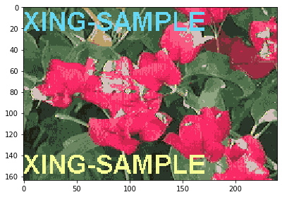

```python
k_means_compress(img_flower, 16)
```

### Question 1.2

The k_means_compress_poor function below is an exact replication of the k_means_compress function above, but with a poor centroid initialization strategy.

```python
def k_means_compress_poor(image, k):

    pixels = image.reshape(image.shape[0]*image.shape[1], 3)

    n = pixels.shape[1]

    c = np.zeros((k, n))

    for i in range(k):

        c[i, 0] = np.clip(pixels[random.randint(0,pixels.shape[0]), 0],0,100)
        c[i, 1] = np.clip(pixels[random.randint(0,pixels.shape[0]), 1],0,100)
        c[i, 2] = np.clip(pixels[random.randint(0,pixels.shape[0]), 2],0,100)

    c_updated = copy.deepcopy(c) + 10
    labels = np.zeros(pixels.shape[0])

    start_time = time.time()

    iterations = 0

    # from kmeans demo code
    while np.linalg.norm(c - c_updated, ord='fro') > 10:

        c = c_updated.copy()

        # updating label assignments
        for i in range(pixels.shape[0]):

            dist = np.zeros(c.shape[0])

            for j in range(c.shape[0]):
                dist[j] = np.linalg.norm(pixels[i] - c[j])

            labels[i] = np.argmin(dist)

        # adjust cluster centers
        for i in range(c.shape[0]):
            subset = pixels[np.where(labels == i)]
            c_updated[i] = (int(np.nan_to_num(pixels[np.where(labels == i)][:,0].mean()))
                            ,int(np.nan_to_num(pixels[np.where(labels == i)][:,1].mean()))
                            ,int(np.nan_to_num(pixels[np.where(labels == i)][:,2].mean())))

        iterations+=1

    print("--- %s seconds ---" % (time.time() - start_time))
    print("--- %s iterations ---" % (iterations))

    h, w = image.shape[0], image.shape[1]

    cluster_assignment = labels.copy()
    labels = np.reshape(labels, (h, w))

    output = np.ones((h, w, 3), dtype = np.uint8)

    output[:,:,:] = c[labels.astype(int),:]

    io.imshow(output)

    return cluster_assignment, c_updated
```

### Comparing random cluster initialization to poor cluster initialization using the sample image

After multiple runs using the sample image and k=4, it is clear that random cluster initialization is a superior method to the poor cluster initialization strategy.

Metrics from each initialization strategy, along with the accompanying compressed images, are below:

- **random initialization**: 7.5 second runtime (slower), 6 iterations (same), better quality compressed image with more distinct color groupings
- **poor initialization**: 7.27 second runtime (faster), 6 iterations (same), worse quality compressed image with less distinct color groupings

Although the same number of iterations were needed for each method, the compression using random initialization consistently required more runtime. This is likely a result of the poor initialization strategy converging to local optima before the random intialization strategy could converge to more useful & distant optima. As seen in the images below, the image produced via random initialization has more distinct color groupings, indicating a more effective spread of initial cluster centers.

```
--- 7.513904809951782 seconds ---
--- 6 iterations ---
```

```
(array([0., 0., 0., ..., 0., 0., 0.]), array([[ 73.,  88.,  63.],
        [230.,  52.,  98.],
        [102., 216., 244.],
        [209., 198., 158.]]))
```

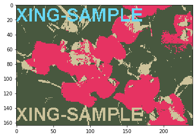

```python
# random initialization
k_means_compress(img_flower, 4)
```

```
--- 7.271868467330933 seconds ---
--- 6 iterations ---
```

```
(array([0., 0., 0., ..., 0., 0., 0.]), array([[ 57.,  73.,  51.],
        [109., 116.,  87.],
        [234.,  52., 100.],
        [190., 211., 186.]]))
```

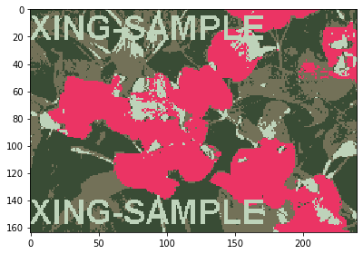

```python
# poor initialization
k_means_compress_poor(img_flower, 4)
```

### Question 1.3

The k_means_compress_manhattan function below is an exact replication of the k_means_compress function above, but using Manhattan distance as the distance metric and adjusting centroid location using median cluster values instead of mean cluster values.

**Comments:** Both the L2-norm and L1-norm distance methods produced compressed images of similar appearance. However, the clustering runtime for the L1-norm method generally required more iterations and a longer runtime to converge. This effect became more pronounced as the number of clusters increased.

The reason for this increase in runtime and iterations when moving from Euclidean distance to Manhattan distance is a result of using the same convergence condition for both methods. Realistically, the clustering using Manhattan distance could have a higher convergence threshold (and therefore not take quite as much runtime) while maintaining a similar effectiveness as the method using Euclidian distance.

```python
def k_means_compress_manhattan(image, k):

    pixels = image.reshape(image.shape[0]*image.shape[1], 3)

    n = pixels.shape[1]

    c = np.zeros((k, n))

    for i in range(k):

        c[i, 0] = np.clip(pixels[random.randint(0,pixels.shape[0]), 0],0,245)
        c[i, 1] = np.clip(pixels[random.randint(0,pixels.shape[0]), 1],0,245)
        c[i, 2] = np.clip(pixels[random.randint(0,pixels.shape[0]), 2],0,245)

    c_updated = copy.deepcopy(c) + 10
    labels = np.zeros(pixels.shape[0])

    start_time = time.time()

    iterations = 0

    # now using Manhattan distance
    while np.sum(np.abs(c - c_updated)) > 10:

        c = c_updated.copy()

        # updating label assignments
        for i in range(pixels.shape[0]):

            dist = np.zeros(c.shape[0])

            for j in range(c.shape[0]):
                # now using Manhattan distance
                dist[j] = np.sum(np.abs(pixels[i] - c[j]))

            labels[i] = np.argmin(dist)

        # adjust cluster centers (now using median)
        for i in range(c.shape[0]):
            subset = pixels[np.where(labels == i)]
            c_updated[i] = (int(np.nan_to_num(np.median(pixels[np.where(labels == i)][:,0])))
                            ,int(np.nan_to_num(np.median(pixels[np.where(labels == i)][:,1])))
                            ,int(np.nan_to_num(np.median(pixels[np.where(labels == i)][:,2]))))

        iterations+=1

    print("--- %s seconds ---" % (time.time() - start_time))
    print("--- %s iterations ---" % (iterations))

    h, w = image.shape[0], image.shape[1]

    cluster_assignment = labels.copy()
    labels = np.reshape(labels, (h, w))

    output = np.ones((h, w, 3), dtype = np.uint8)

    output[:,:,:] = c[labels.astype(int),:]

    io.imshow(output)

    return cluster_assignment, c_updated
```

#### football.bmp

Below are the runtimes and iterations for k-means clustering convergence for the football.bmp image compression (using Manhattan distance):

Compressed images are displayed in order below, along with 1) each pixel's class and 2) centroid locations.

```
--- 22.76741075515747 seconds ---
--- 5 iterations ---
```

```
(array([0., 0., 0., ..., 0., 0., 0.]), array([[ 77.,  80.,  73.],
        [194., 184., 173.]]))
```

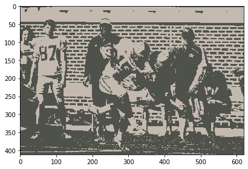

```python
k_means_compress_manhattan(img_football, 2)
```

```
--- 38.06762194633484 seconds ---
--- 5 iterations ---
```

```
(array([1., 1., 1., ..., 1., 1., 1.]), array([[183., 165., 149.],
        [116., 112.,  87.],
        [216., 219., 221.],
        [ 31.,  41.,  35.]]))
```

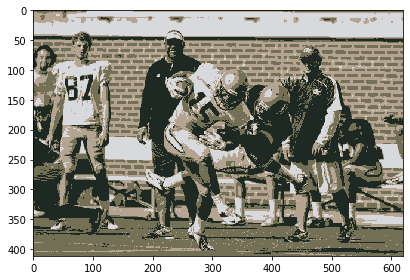

```python
k_means_compress_manhattan(img_football, 4)
```

```
--- 192.64198303222656 seconds ---
--- 14 iterations ---
```

```
(array([1., 1., 1., ..., 3., 3., 3.]), array([[160., 106.,  84.],
        [ 69.,  68.,  51.],
        [ 20.,  22.,  20.],
        [114., 130.,  93.],
        [ 25.,  64., 116.],
        [183., 159., 137.],
        [191., 184., 181.],
        [220., 223., 224.]]))
```

[figure not shown]

```python
k_means_compress_manhattan(img_football, 8)
```

```
--- 552.2890989780426 seconds ---
--- 19 iterations ---
```

```
(array([ 7.,  7.,  7., ..., 11., 11., 11.]), array([[ 55.,  52.,  37.],
        [100.,  99.,  76.],
        [ 33.,  33.,  24.],
        [183., 159., 140.],
        [ 57.,   6.,   7.],
        [119., 129., 139.],
        [191., 185., 183.],
        [ 74.,  75.,  57.],
        [ 38.,  74., 132.],
        [ 16.,  19.,  20.],
        [  6.,   8.,   8.],
        [120., 142.,  89.],
        [217., 199., 129.],
        [220., 224., 225.],
        [ 10.,  48.,  92.],
        [162., 109.,  86.]]))
```

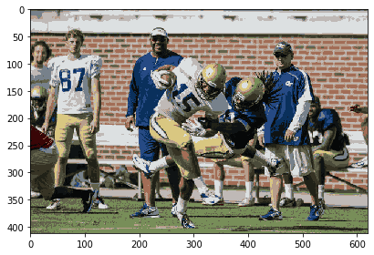

```python
k_means_compress_manhattan(img_football, 16)
```

#### GeorgiaTech.bmp

Below are the runtimes and iterations for k-means clustering convergence for the GeorgiaTech.bmp image compression (using Manhattan distance):

- k=2: 12 second runtime, 4 iterations (Euclidean)
- k=2: 9 second runtime, 3 iterations (Manhattan)
- k=4: 21 second runtime, 4 iterations (Euclidean)
- k=4: 22 second runtime, 4 iterations (Manhattan)
- k=8: 65 second runtime, 7 iterations (Euclidean)
- k=8: 219 second runtime, 21 iterations (Manhattan)
- k=16: 155 second runtime, 9 iterations (Euclidean)
- k=16: 375 second runtime, 20 iterations (Manhattan)

Compressed images are displayed in order below, along with 1) each pixel's class and 2) centroid locations.

```
--- 9.383878231048584 seconds ---
--- 3 iterations ---
```

```
(array([0., 0., 0., ..., 1., 1., 1.]), array([[165., 158., 165.],
        [ 51.,  51.,  33.]]))
```

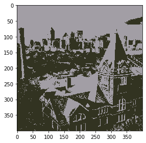

```python
k_means_compress_manhattan(img_gatech, 2)
```

```
--- 22.123305082321167 seconds ---
--- 4 iterations ---
```

```
(array([2., 2., 2., ..., 1., 1., 1.]), array([[136., 157., 175.],
        [ 39.,  34.,  27.],
        [222., 173., 140.],
        [ 96.,  91.,  78.]]))
```

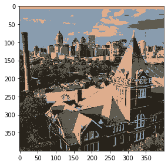

```python
k_means_compress_manhattan(img_gatech, 4)
```

```
--- 218.72900366783142 seconds ---
--- 21 iterations ---
```

```
(array([2., 2., 2., ..., 5., 4., 4.]), array([[136., 159., 181.],
        [ 90., 123., 143.],
        [255., 255., 255.],
        [204., 180., 172.],
        [ 35.,  29.,  24.],
        [ 62.,  64.,  63.],
        [116.,  95.,  59.],
        [213., 146.,  96.]]))
```

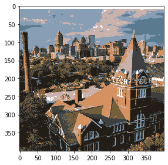

```python
k_means_compress_manhattan(img_gatech, 8)
```

```
--- 374.9333162307739 seconds ---
--- 20 iterations ---
```

```
(array([0., 0., 0., ..., 5., 2., 2.]), array([[255., 255., 255.],
        [152., 121.,  99.],
        [ 52.,  41.,  29.],
        [ 30.,  25.,  22.],
        [ 37.,  52.,  61.],
        [ 85.,  71.,  32.],
        [136., 161., 183.],
        [231., 200., 182.],
        [219., 168., 126.],
        [179., 169., 172.],
        [ 60.,  73.,  84.],
        [ 88., 133., 160.],
        [130., 101.,  37.],
        [206., 149.,  96.],
        [101.,  93.,  90.],
        [245., 118.,  42.]]))
```

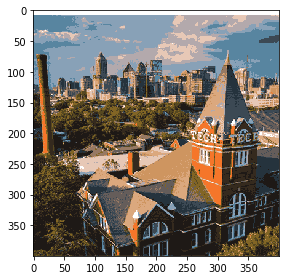

```python
k_means_compress_manhattan(img_gatech, 16)
```

#### XING_B24.bmp (my sample image)

Below are the runtimes and iterations for k-means clustering convergence for the XING_B24.bmp image compression (using Manhattan distance):

Compressed images are displayed in order below, along with 1) each pixel's class and 2) centroid locations.

```
--- 4.951285123825073 seconds ---
--- 7 iterations ---
```

```
(array([0., 0., 0., ..., 0., 0., 0.]), array([[ 74.,  95.,  66.],
        [244.,  63., 110.]]))
```

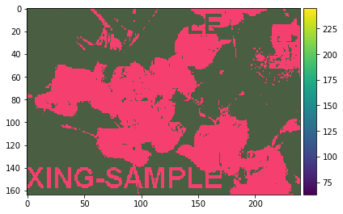

```python
k_means_compress_manhattan(img_flower, 2)
```

```
--- 7.715327024459839 seconds ---
--- 6 iterations ---
```

```
(array([1., 1., 1., ..., 1., 1., 1.]), array([[243.,  49.,  98.],
        [ 69.,  92.,  63.],
        [211., 192., 147.],
        [102., 216., 244.]]))
```

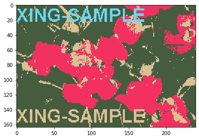

```python
k_means_compress_manhattan(img_flower, 4)
```

```
--- 18.755235195159912 seconds ---
--- 8 iterations ---
```

```
(array([5., 5., 5., ..., 4., 4., 4.]), array([[ 86., 116.,  81.],
        [128., 146., 108.],
        [205.,  41.,  80.],
        [247., 206., 162.],
        [ 43.,  51.,  42.],
        [ 62.,  90.,  61.],
        [255.,  58., 111.],
        [102., 216., 244.]]))
```

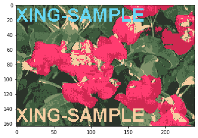

```python
k_means_compress_manhattan(img_flower, 8)
```

```
--- 30.149405479431152 seconds ---
--- 7 iterations ---
```

```
(array([ 2., 15.,  2., ..., 12., 12., 12.]), array([[255.,  42., 102.],
        [112., 139., 101.],
        [ 69., 103.,  68.],
        [ 87., 118.,  83.],
        [247., 253., 147.],
        [160., 163., 130.],
        [ 36.,  41.,  34.],
        [208.,  63.,  94.],
        [102., 216., 244.],
        [202., 195., 190.],
        [145.,  49.,  65.],
        [220.,  26.,  77.],
        [ 45.,  57.,  46.],
        [ 58.,  73.,  58.],
        [255.,  82., 128.],
        [ 55.,  89.,  53.]]))
```

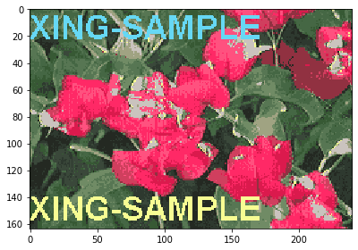

```python
k_means_compress_manhattan(img_flower, 16)
```

## Question 2: Spectral clustering and discover football colleague

```python
import numpy as np
import time
import matplotlib.pyplot as plt
from scipy.sparse import csc_matrix, find
from itertools import combinations
import copy
```

### Question 2.1

Create adjacency matrix using the simple graph provided:

```python
A = np.matrix([[0, 1, 1, 0, 0],
               [1, 0, 1, 0, 0],
               [1, 1, 0, 0, 0],
               [0, 0, 0, 0, 1],
               [0, 0, 0, 1, 0]])
A
```

```
matrix([[0, 1, 1, 0, 0],
        [1, 0, 1, 0, 0],
        [1, 1, 0, 0, 0],
        [0, 0, 0, 0, 1],
        [0, 0, 0, 1, 0]])
```

Generate the degree matrix using the adjacency matrix (formed by summing the number of adjacent nodes for each of the 5 nodes in the graph)

```python
D = np.matrix([[2, 0, 0, 0, 0],
               [0, 2, 0, 0, 0],
               [0, 0, 2, 0, 0],
               [0, 0, 0, 1, 0],
               [0, 0, 0, 0, 1]])
D
```

```
matrix([[2, 0, 0, 0, 0],
        [0, 2, 0, 0, 0],
        [0, 0, 2, 0, 0],
        [0, 0, 0, 1, 0],
        [0, 0, 0, 0, 1]])
```

```python
L = D - A
L
```

```
matrix([[ 2, -1, -1,  0,  0],
        [-1,  2, -1,  0,  0],
        [-1, -1,  2,  0,  0],
        [ 0,  0,  0,  1, -1],
        [ 0,  0,  0, -1,  1]])
```

```python
from scipy.linalg import eig

eig_val, eig_vec = eig(L)

print('eigenvalues: ')
print(eig_val)
print('eigenvectors: ')
print(eig_vec)
```

```
eigenvalues:
[ 3.00000000e+00+0.j -1.11022302e-16+0.j  3.00000000e+00+0.j
  2.00000000e+00+0.j  0.00000000e+00+0.j]
eigenvectors:
[[ 0.81649658 -0.57735027  0.30959441  0.          0.        ]
 [-0.40824829 -0.57735027 -0.80910101  0.          0.        ]
 [-0.40824829 -0.57735027  0.49950661  0.          0.        ]
 [ 0.          0.          0.          0.70710678  0.70710678]
 [ 0.          0.          0.         -0.70710678  0.70710678]]
```

Eigenvectors associated with zero eigenvalue:

```python
print('zero eigenvalue: ')
print(eig_val[1])
print('eigenvector: ')
print(eig_vec[1])
print('\nzero eigenvalue: ')
print(eig_val[4])
print('eigenvector: ')
print(eig_vec[4])
```

```
zero eigenvalue:
(-1.1102230246251565e-16+0j)
eigenvector:
[-0.40824829 -0.57735027 -0.80910101  0.          0.        ]

zero eigenvalue:
0j
eigenvector:
[ 0.          0.          0.         -0.70710678  0.70710678]
```

#### Explanation:

The multiplicty of the eigenvalue 0 is 2, corresponding to 2 connected components in the graph.

These 2 eigenvectors include cluster assignment information. The first eignvector has nonzero values in positions 0, 1, and 2, corresponding to the cluster between nodes 1, 2, and 3 in the graph. The second eigenvector has nonzero values in positions 3 and 4, corresponding to the cluster between nodes 4 and 5 in the graph.

### Question 2.2

```python
#code below is adapted from the provided demo code

import os
import numpy as np
from os.path import abspath, exists
from scipy import sparse
import scipy
from sklearn.cluster import KMeans
from matplotlib import pyplot as plt


def output_file(a, idx2name, c_idx):
    dirpath = os.getcwd()
    node_file = dirpath + '//nodes.csv'
    edge_file = dirpath + '//edges.csv'

    with open(edge_file, 'w') as fid:
        fid.write('Source\tTarget\n')
        for i in range(len(a)):
            fid.write(f'{a[i,0]}\t{a[i,1]}\n')

    with open(node_file, 'w') as fid:
        fid.write('Id\tLabel\tColor\n')
        for i in range(len(idx2name)):
            fid.write(f'{i}\t{idx2name[i]}\t{c_idx[i]}\n')


def read_team_name():
    # read inverse_teams.txt file
    f_path = abspath("inverse_teams.txt")
    idx2name = []
    if exists(f_path):
        with open(f_path) as fid:
            for line in fid.readlines():
                name = line.split("\t", 1)[1]
                idx2name.append(name[:-1])
    return idx2name


def import_graph():
    # read the graph from 'play_graph.txt'
    f_path = abspath("play_graph.txt")
    if exists(f_path):
        with open(f_path) as graph_file:
            lines = [line.split() for line in graph_file]
    return np.array(lines).astype(int)


# load the graph
a = import_graph()

n = 321

i = a[:, 0]-1
j = a[:, 1]-1
v = np.ones((a.shape[0], 1)).flatten()

A = sparse.coo_matrix((v, (i, j)), shape=(n, n))
A = (A + np.transpose(A))/2
A = sparse.csc_matrix.todense(A) # ## convert to dense matrix

D = np.diag(1/np.sqrt(np.sum(A, axis=1)).A1) # taking -1/2 power of diagonal matrix
L = D @ A @ D # normalized Laplacian, therefore want to find the largest eigenvalues
L = np.array(L) # ## convert to array

# v, x = np.linalg.eig(L)
# x = x[:, 0:k].real

# eigendecompoosition
v, x= np.linalg.eig(L)
idx_sorted = np.argsort(v) # the index of eigenvalue sorted acsending
#v[idx_sorted].real[::-1] # eigenvalues sorted from largest to smallest
```

The eigendecomposition of the normalized Laplacian matrix is above. Below are the plotted eigenvalues (ranked largest to smallest).

Based on the plot, I would say there should be approximately 17 clusters. I am choosing about 17 clusters because, when considering the normalized Laplacian's eigendecomposition, one wants to select the k largest eigenvalues. After the first 17 or so sorted eigenvalues, there is a large drop in value (from ~0.6 to ~0.4). I would treat this as a distinct cutoff for the "large" eigenvalues.

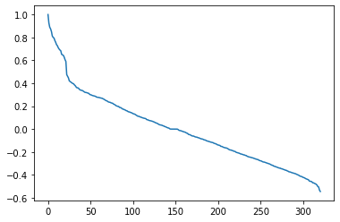

```python
plt.plot(v[idx_sorted].real[::-1])
```

### Question 2.3

The cells below display the largest and smallest cluster sizes for **k = 5, 7, 10,** and **17** (*my approximation*)

### k=5

```python
# eigendecompoosition
v, x= np.linalg.eig(L)
idx_sorted = np.argsort(v) # the index of eigenvalue sorted acsending
#v[idx_sorted].real[::-1] # eigenvalues sorted from largest to smallest

# spectral clustering
k = 5

x = x[:, idx_sorted[-k:]] # select the k largest eigenvectors

x = x/np.repeat(np.sqrt(np.sum(x*x, axis=1).reshape(-1, 1)), k, axis=1)

# # scatter
# plt.scatter(x[:, 0], x[:, 1])
# plt.show()

# convert x to real numbers
x = x.real

# k-means with k=5
kmeans = KMeans(n_clusters=k).fit(x)
c_idx = kmeans.labels_
c_idx

print('Largest cluster size: ', np.where(c_idx==np.bincount(c_idx).argmax())[0].shape[0])
print('Smallest cluster size: ', np.where(c_idx==np.bincount(c_idx).argmin())[0].shape[0])
```

```
Largest cluster size:  106
Smallest cluster size:  36
```

### k=7

```python
# eigendecompoosition
v, x= np.linalg.eig(L)
idx_sorted = np.argsort(v) # the index of eigenvalue sorted acsending
#v[idx_sorted].real[::-1] # eigenvalues sorted from largest to smallest

# spectral clustering
k = 7

x = x[:, idx_sorted[-k:]] # select the k largest eigenvectors

x = x/np.repeat(np.sqrt(np.sum(x*x, axis=1).reshape(-1, 1)), k, axis=1)

# # scatter
# plt.scatter(x[:, 0], x[:, 1])
# plt.show()

# convert x to real numbers
x = x.real

# k-means with k=7
kmeans = KMeans(n_clusters=k).fit(x)
c_idx = kmeans.labels_
c_idx

print('Largest cluster size: ', np.where(c_idx==np.bincount(c_idx).argmax())[0].shape[0])
print('Smallest cluster size: ', np.where(c_idx==np.bincount(c_idx).argmin())[0].shape[0])
```

```
Largest cluster size:  94
Smallest cluster size:  18
```

### k=10

```python
# eigendecompoosition
v, x= np.linalg.eig(L)
idx_sorted = np.argsort(v) # the index of eigenvalue sorted acsending
#v[idx_sorted].real[::-1] # eigenvalues sorted from largest to smallest

# spectral clustering
k = 10

x = x[:, idx_sorted[-k:]] # select the k largest eigenvectors

x = x/np.repeat(np.sqrt(np.sum(x*x, axis=1).reshape(-1, 1)), k, axis=1)

# # scatter
# plt.scatter(x[:, 0], x[:, 1])
# plt.show()

# convert x to real numbers
x = x.real

# k-means with k=10
kmeans = KMeans(n_clusters=k).fit(x)
c_idx = kmeans.labels_
c_idx

print('Largest cluster size: ', np.where(c_idx==np.bincount(c_idx).argmax())[0].shape[0])
print('Smallest cluster size: ', np.where(c_idx==np.bincount(c_idx).argmin())[0].shape[0])
```

```
Largest cluster size:  63
Smallest cluster size:  18
```

### k=17

```python
# eigendecompoosition
v, x= np.linalg.eig(L)
idx_sorted = np.argsort(v) # the index of eigenvalue sorted acsending
#v[idx_sorted].real[::-1] # eigenvalues sorted from largest to smallest

# spectral clustering
k = 17

x = x[:, idx_sorted[-k:]] # select the k largest eigenvectors

x = x/np.repeat(np.sqrt(np.sum(x*x, axis=1).reshape(-1, 1)), k, axis=1)

# # scatter
# plt.scatter(x[:, 0], x[:, 1])
# plt.show()

# convert x to real numbers
x = x.real

# k-means with k=17
kmeans = KMeans(n_clusters=k).fit(x)
c_idx = kmeans.labels_
c_idx

print('Largest cluster size: ', np.where(c_idx==np.bincount(c_idx).argmax())[0].shape[0])
print('Smallest cluster size: ', np.where(c_idx==np.bincount(c_idx).argmin())[0].shape[0])
```

```
Largest cluster size:  28
Smallest cluster size:  10
```

Cluster results for k = 10, listing the teams that belong to each cluster

```python
# eigendecompoosition
v, x= np.linalg.eig(L)
idx_sorted = np.argsort(v) # the index of eigenvalue sorted acsending
#v[idx_sorted].real[::-1] # eigenvalues sorted from largest to smallest

# spectral clustering
k = 10

x = x[:, idx_sorted[-k:]] # select the k largest eigenvectors

x = x/np.repeat(np.sqrt(np.sum(x*x, axis=1).reshape(-1, 1)), k, axis=1)

# # scatter
# plt.scatter(x[:, 0], x[:, 1])
# plt.show()

# convert x to real numbers
x = x.real

# k-means with k=10
kmeans = KMeans(n_clusters=k).fit(x)
c_idx = kmeans.labels_

# show cluster
idx2name = read_team_name()
for i in range(k):
    print(f'Cluster {i+1}\n***************')
    idx = [index for index, t in enumerate(c_idx) if t == i]
    for index in idx:
        print(idx2name[index])
    print('\n')

# output file
output_file(a, idx2name, c_idx)

print('Largest cluster size: ', np.where(c_idx==np.bincount(c_idx).argmax())[0].shape[0])
print('Smallest cluster size: ', np.where(c_idx==np.bincount(c_idx).argmin())[0].shape[0])
```

```
Cluster 1
***************
Virginia-Lynchburg
Alcorn St.
Faith U.
Mississippi Valley St.
Southern
Ark.-Pine Bluff
Jackson St.
Alabama St.
Grambling
Alabama A&M
Prairie View A&M
Texas Southern
Tuskegee
Concordia
Central Methodist
Stillman College
Louisiana College
Central State (Ohio)


Cluster 2
***************
Georgia State
Texas A&M
South Carolina
Wake Forest
La.-Monroe
Ole Miss
New Mexico St.
Vanderbilt
Syracuse
Virginia
Pittsburgh
Navy
Troy
UAB
Appalachian St.
Kentucky
```

[output cut: 308 more lines]

```
Assumption
Harvard
Yale
Brown
Columbia
Cornell
Penn
Princeton
Dartmouth
West Liberty State
Alderson Broaddus


Largest cluster size:  60
Smallest cluster size:  18
```

### Question 2.4

Results between different runs of k-means clustering with k=10 are slightly different because of how the clusters are initialized. The default initialization strategy, 'k-means++', speeds up the convergence process (when compared to random initialization) but still changes from run to run. This is why the clusters are slightly different between runs.

Between all of my k=10 runs, “Georgia Tech”, “Georgia State”, and “Georgia” (UGA) have always been in the same cluster. Despite the changing cluster initialization mentioned above, “Georgia Tech”, “Georgia State”, and “Georgia” must be interconnected enough that the vast majority of initializations will still group them togther into the same cluster.

### Question 2.5

When repeatedly running k-means with k=10, the sizes of the largest and smallest clusters changed slightly with every run. I found this interesting because it was a direct view into the fact that we use k-means as a heuristic and, although it is very useful, it will not provide the optimal solution every time it is used.